# CBC 2021 data visualization

An Bui

January 2022

# 0. Introduction

## a. Where’d the data come from?

The data presented below are observations from the Santa Rosa count on the 28th of December 2021 (FHJ, MH, AB) and the Cacao count on the 30th of December 2021 (FHJ, RVJ, MH, AB).

## b. Organization

This document is set up to show all the code involved in the visualizations for transparency, and I’ve tried to annotate the code as much as possible so that folks can have a sense of what they’re looking at. However, you can use the table of contents to the left to skip through the code walk-throughs to get to the plots. Additionally, a cleaned up, no-code version is available in PDF form [here](https://fjoyce.github.io/ACG-CBC-data/code/ACG-CBC-data-summary-2021-no_code.pdf) if you would prefer that.

# 1. Set up

## a. Libraries

One of the big selling points for using R is the fact that you can take advantage of packages. Packages are collections of code that people have written to do very specific things, and the ones below are what I am using.

```r
library(tidyverse) # general manipulation
library(here) # organizing directories
library(janitor) # cleaning column names
library(BiodiversityR) # to make rank abundance curve
library(ggrepel) # repel ggplot text labels
library(tanagR) # color palettes inspired by members of the Thraupidae family
library(gt) # making nice looking tables
```

## b. Data

The data format here is called a “data frame”. This is basically the R version of an Excel file in .csv or .xlsx. There are four data frames here:  
1. `taxon_nacc`: taxonomic information from the [NACC](http://checklist.americanornithology.org/)  
2. `murci`: Murciélago counts  
3. `leiva`: Leiva counts  
4. `birds`: data frame with both `murci` and `leiva`

```r
# taxon info from NACC
taxon_nacc <- read_csv(here::here("data", "NACC_list_species_2022-01-29.csv"))

# Murcielago
murci <- read_csv(here::here("data", "CRSR_CBC_2021_Murcielago_data_entry.csv")) %>%
  mutate(sitio = "murci") %>%
  clean_names() %>%
  # attach taxonomic info
  left_join(., taxon_nacc, by = c("especie" = "common_name"))

# Leiva
leiva <- read_csv(here::here("data", "CRCA_CBC_2021_Leiva_Sensoria_data_entry.csv")) %>%
  mutate(sitio = "leiva") %>%
  clean_names() %>%
  # attach taxonomic info
  left_join(., taxon_nacc, by = c("especie" = "common_name"))

# Murcielago and Leiva together in one data frame
birds <- rbind(murci, leiva)
```

# 2. Basic information

## a. Code

**How many species did we see on each count? How many species did we see on both counts?**

To answer this, I made a new data frame called `all_species` with a column for each species, and columns marking “yes” or “no” for observations. I also found the number of unique species for each count and saved that value as `murci_total_spp` and `leiva_total_spp`.

One tricky thing I wanted to do was order the species by family. To do this, I created a vector called `family_levels` that was a vector of all the families in the right order. Then, I could use that vector to order species by family.

```r
family_levels <- taxon_nacc %>%
  select(family) %>%
  unique() %>%
  mutate(family = fct_inorder(family)) %>%
  pull(family)

all_species <- birds %>%
  # get unique species for each site
  select(sitio, family, especie) %>%
  unique() %>%
  # create a new column called observed
  mutate(observed = "yes") %>%
  # create 2 new columns: murci and leiva, where the entries are yes/NA for an observation
  pivot_wider(names_from = "sitio", values_from = "observed") %>%
  # replace any NA with "no"
  replace(is.na(.), "no") %>%
  # arrange in order by family
  arrange(factor(family, levels = family_levels)) %>%
  # replace the missing `family` value for the sloth
  mutate(family = case_when(
    family == "no" ~ "Choloepodidae (Mammalia)",
    TRUE ~ as.character(as.character(family))
  ))

# finding the total species observed at Murciélago
murci_total_spp <- unique(murci$especie) %>%
  length()

# finding the total species observed at Leiva
leiva_total_spp <- unique(leiva$especie) %>%
  length()

# finding the species observed at both Leiva and Murciélago
both_total_spp <- all_species %>%
  filter(murci == "yes" & leiva == "yes") %>%
  nrow()
```

**How many individual birds did we see (probably)?**

To answer this question, I calculated the sum of individuals from the `numero` column from Murciélago and Leiva.

```r
murci_ind <- sum(murci$numero)

leiva_ind <- sum(leiva$numero)
```

## b. Outputs

**How many species did we see on each count? How many species did we see on both counts?**

```r
all_species %>%
  gt(groupname_col = "family") %>%
  tab_header(title = md("Species observed")) %>%
  # indent the species
  tab_style(
    style = cell_text(indent = pct(5)),
    locations = cells_body(
      columns = especie)
  ) %>%
  # color the family rows
  tab_style(
    style = cell_fill(color = "lightgray"),
    locations = cells_row_groups()
  ) %>%
  # make the family rows bold
  tab_style(
    style = cell_text(weight = "bold"),
    locations = cells_row_groups()
  )
```

Species observed

| especie | murci | leiva |
| --- | --- | --- |
| Tinamidae |  |  |
| Thicket Tinamou | yes | no |
| Cracidae |  |  |
| Crested Guan | no | yes |
| Columbidae |  |  |
| White-tipped Dove | yes | yes |
| Inca Dove | yes | no |
| White-winged Dove | yes | yes |
| Red-billed Pigeon | yes | no |
| Short-billed Pigeon | no | yes |
| Ruddy Ground Dove | no | yes |
| Cuculidae |  |  |
| Squirrel Cuckoo | yes | yes |
| Groove-billed Ani | yes | yes |
| Caprimulgidae |  |  |
| Common Pauraque | yes | yes |
| Lesser Nighthawk | yes | no |
| Nyctibiidae |  |  |
| Northern Potoo | yes | no |
| Apodidae |  |  |
| White-collared Swift | no | yes |
| Lesser Swallow-tailed Swift | no | yes |
| Trochilidae |  |  |
| Blue-vented Hummingbird | yes | no |
| Cinnamon Hummingbird | yes | no |
| Ruby-throated Hummingbird | yes | no |
| Rufous-tailed Hummingbird | no | yes |
| Stripe-throated Hermit | no | yes |
| Scaly-breasted Hummingbird | no | yes |
| Rallidae |  |  |

[output cut: 169 more lines]

# 2. Observations by family

I was curious about the number of observations by family (I would not, for example, expect many observations of Trochilidae regardless of how many there may have been flitting around…). To do this, I calculated the total number of observed individuals for each family for each count, and made a bar graph displaying all families detected.

## a. Code

There are two code chunks here. The first calculates the total number of observed individuals of each family in each count. Since I’m doing this twice (once for `murci`, and once for `leiva`), I created a function called `family_summary` so that I wouldn’t have to rewrite (or, realistically, copy/paste) the same code twice. The objects that come out of this are `murci_familiies` and `leiva_families`.

```r
family_summary <- function(df) {
  df %>%
    group_by(family) %>%
    # summarizing observations by family
    group_by(family) %>%
    summarize(sum_obs = sum(numero)) %>%
    ungroup() %>%
    # set the factor levels to be in descending order by sum_obs
    arrange(-sum_obs) %>%
    mutate(family = fct_inorder(family))
}

murci_families <- family_summary(murci)

leiva_families <- family_summary(leiva)
```

The second code chunk creates the bar plots: columns for each family with a label indicating how many individuals were observed. Similarly to what I did above, I created a function to put all the same code in one place. The objects here are called `murci_families_bar` and `leiva_families_bar`.

```r
barplot_format <- function(df) {
  ggplot(df, aes(x = family, y = sum_obs)) +
    geom_col(aes(fill = family)) +
    geom_text(aes(label = sum_obs), nudge_y = max(df$sum_obs*0.02)) +
    scale_y_continuous(expand = c(0, 0), limits = c(0, max(df$sum_obs*1.05))) +
    theme_classic() +
    theme(legend.position = "none",
          axis.text.x = element_text(angle = -45, hjust = 0, size = 14),
          axis.title = element_text(size = 20),
          title = element_text(size = 25),
          plot.margin = margin(2, 2, 2, 2, "cm"))
}

murci_families_barplot <- barplot_format(murci_families) +
  # use the Tangara chilensis color palette
  scale_fill_manual(values = tanagr_palette("tangara_chilensis", n = 38, discrete = FALSE)) +
  labs(x = "Family", y = "Total individuals observed",
       title = "Murciélago observations by family")

leiva_families_barplot <- barplot_format(leiva_families) +
  # use the Cyanerpes cyaneus color palette
  scale_fill_manual(values = tanagr_palette("cyanerpes_cyaneus", n = 34, discrete = FALSE)) +
  labs(x = "Family", y = "Total individuals observed",
       title = "Leiva observations by family")
```

## b. Plots

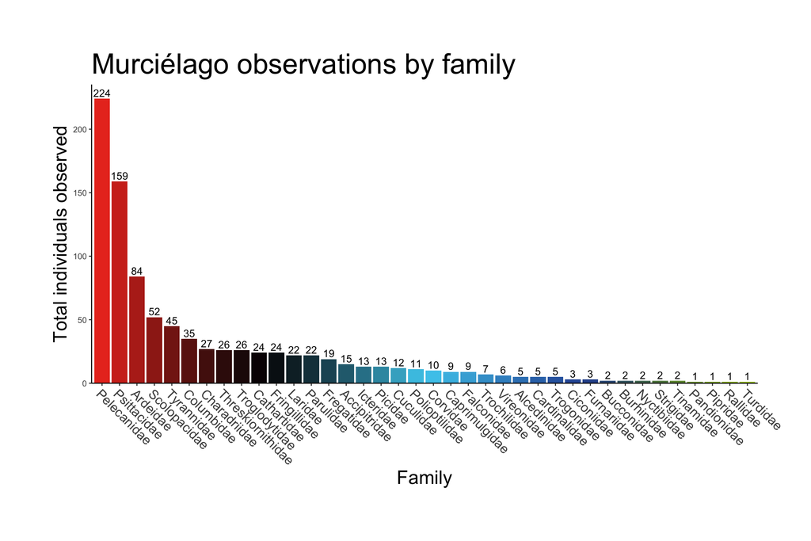

```r
murci_families_barplot
```

We saw *a lot* of Brown Pelicans on our Santa Rosa count. Also, lots of parrots! Seems they are not locally extinct after all.

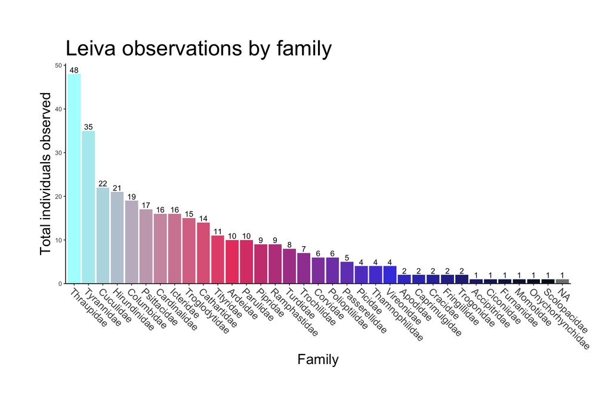

```r
leiva_families_barplot
```

# 2. Rank abundance

## a. What is a rank abundance curve?

Rank abundance curves are plotted with the proportion (or raw number of) observations for each species on the y-axis, and rank on the x-axis. From these plots, you can glean information about how abundant species were in your data.

## b. Code

First, I’ll make a data frame to calculate rank abundance where each column is a species (n = 150) and each row is a “site” (n = 2, either “leiva” or “murci”). The cells are filled with the total number of observations for each species.

```r
# use the `birds` data frame
birds_ra_df <- birds %>%
  # select site, species, and number
  select(sitio, especie, numero) %>%
  # calculate total number of observations per species per site
  group_by(sitio, especie) %>%
  summarize(sum_obs = sum(numero)) %>%
  # spread out the data frame so that each column is a species
  pivot_wider(names_from = especie, values_from = sum_obs) %>%
  column_to_rownames("sitio") %>%
  # replace any NA with 0
  replace(is.na(.), 0)
```

I’ll also make a data frame with the site information: not especially informative, but useful for plotting the data later.

```r
# use the `dplyr::tribble()` function
env <- tribble(
  # create one column called "sitio" with "leiva" and "murci"
  ~sitio,
  "leiva",
  "murci") %>%
  # make sure this is a data.frame
  as.data.frame() %>%
  # set the factors
  mutate(sitio = as_factor(sitio))
```

To make the plot, I’ll use the `BiodiversityR::rankabundance()` function to calculate rank abundance for Leiva and Murciélago.

```r
ra_code <- function(sitio) {
  rankabundance(x = birds_ra_df,
                y = env, factor = "sitio",
                level = c(sitio)) %>%
    as.data.frame() %>%
    rownames_to_column("especie") %>%
    select(-plower, -pupper)
}

murci_ra_data <- ra_code("murci")

leiva_ra_data <- ra_code("leiva")
```

Plot code below, with a function to keep things tidy.

```r
ra_formatting <- function(df) {
  ggplot(df, aes(x = rank, y = proportion)) +
    geom_line(size = 1) +
    geom_point(size = 2) +
    geom_text_repel(data = df %>% filter(rank < 10),
                    aes(label = especie),
                    segment.curvature = -1e-20, point.padding = 0.2,
                    force_pull = 10, direction = "y",
                    nudge_x = 15, nudge_y = 0.1,
                    size = 5, col = "red") +
    theme_bw() +
    theme(axis.title = element_text(size = 13),
          title = element_text(size = 15))
}

murci_ra_plot <- ra_formatting(murci_ra_data) +
  labs(x = "Rank", y = "Proportion of total individuals observed",
       title = "Murciélago count rank abundance")

leiva_ra_plot <- ra_formatting(leiva_ra_data) +
  labs(x = "Rank", y = "Proportion of total individuals observed",
       title = "Leiva count rank abundance")
```

## b. Plots

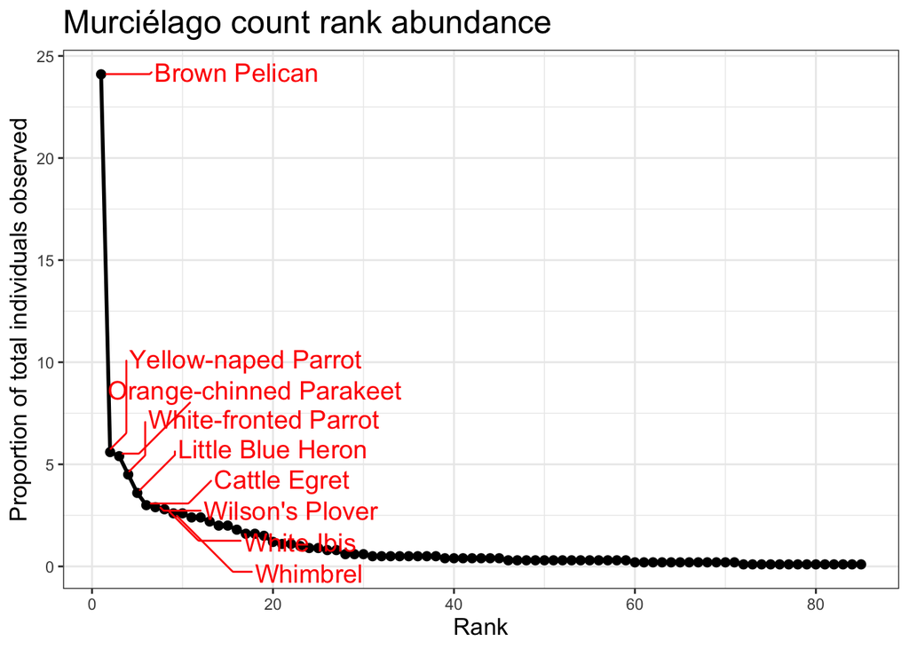

```r
murci_ra_plot
```

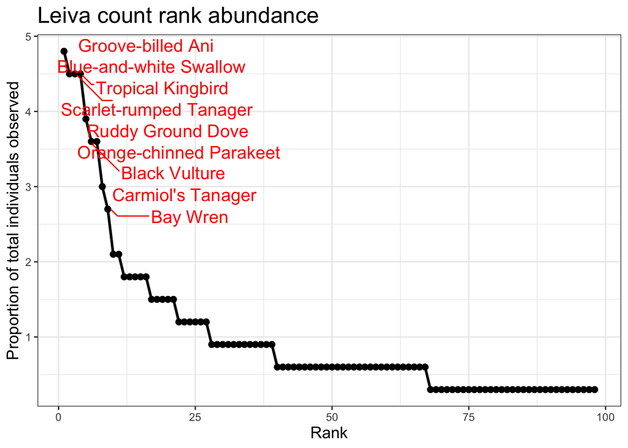

```r
leiva_ra_plot
```